# simon-5502-02-slides

## Topics to be covered

- Add a topic next year on leverage, studentized residuals, Cook’s distance
- What you will learn
  - Three models for predicting a continuous outcome
  - Analysis of variance table
  - Variable selection
  - Stepwise regression
  - Residual analysis
  - Collinearity
  - Mediation

## Three models

- All use a continuous dependent (outcome) variables
- All include multiple independent variables
- Multiple linear regression (Week 02)
  - All independent variables are continuous
- Analysis of covariance (Week 03)
  - Mix of continuous and categorical independent variables
- Multi-factor analysis of variance (Week 04)
  - All independent variables are categorical

## Why three models?

- Historical precedents
- Different issues
  - Multicollinearity
  - Mediator variable
  - Risk adjustment
  - Moderator variable
  - Interactions

## The general linear model

- Single model that unites all three models.
- Use of indicator variables for categorical data
- Not the same as general **IZED** linear model
  - SAS: proc glm versus proc glim
  - R: lm() versus glm()

## Arguments for the lm() function

- formula = $dependent-variable$ ~ $independent-variables$
  - $independent-variables$ can be numeric, factors, or strings
- data =
- subset =
- [na.action](https://stat.ethz.ch/R-manual/R-devel/library/stats/html/na.fail.html) =
  - na.fail
  - na.omit
  - na.exclude
- other arguments

## Live demo #1, ANOVA and R-squared

Refer to the [demonstration program for module02](https://github.com/pmean/classes/blob/master/biostats-2/02/src/simon-5502-02-demo.qmd).

## Break #1

- What you have learned
  - Three models for predicting a continuous outcome
- What’s coming next
  - Analysis of variance table

## Data for multiple linear regression

- Dependent variable: $Y_1, Y_2,\ldots,Y_n$
- First independent variable: $X_{11}, X_{12}, \ldots, X_{1n}$
- Second independent variable: $X_{21}, X_{22}, \ldots, X_{2n}$
- …
- kth independent variable: $X_{k1}, X_{k2}, \ldots, X_{kn}$

## Matrix notation, 1 of 3

$$\begin{matrix}Y=& \begin{bmatrix}
Y_1\\
Y_2\\
\vdots\\
Y_{j}\\
\vdots\\
Y_n
\end{bmatrix}
\end{matrix}$$

## Matrix notation, 2 of 3

$$\begin{matrix}X=& \begin{bmatrix}
X_{11} & X_{21} & \ldots & X_{i1} & \ldots & X_{k1}\\
X_{12} & X_{22} & \ldots & X_{i2} & \ldots & X_{k2}\\
\vdots & \vdots & & \vdots & & \vdots\\
X_{1j} & X_{2j} & \ldots & X_{ij} & \ldots & X_{kj}\\
\vdots & \vdots & & \vdots & & \vdots\\
X_{1n} & X_{2n} & \ldots & X_{in} & \ldots & X_{kn}
\end{bmatrix}
\end{matrix}$$

## Matrix notation, 3 of 3

$$\begin{matrix}X=& \begin{bmatrix}
1 & X_{11} & X_{21} & \ldots & X_{i1} & \ldots & X_{k1}\\
1 & X_{12} & X_{22} & \ldots & X_{i2} & \ldots & X_{k2}\\
\vdots & \vdots & \vdots & & \vdots & & \vdots\\
1 & X_{1j} & X_{2j} & \ldots & X_{ij} & \ldots & X_{kj}\\
\vdots & \vdots & \vdots & & \vdots & & \vdots\\
1 & X_{1n} & X_{2n} & \ldots & X_{in} & \ldots & X_{kn}
\end{bmatrix}
\end{matrix}$$

## Why use multiple linear regression

- Two competing purposes
  - Mechanisms
    - What variables have an impact on your outcome?
  - Prediction
    - What outcome will you see on tomorrow’s patient?
    - “It is difficult to make predictions, especially about the future.” Niels Bohr

## Multiple linear regression model

- $Y_i=\beta_0+\beta_1 X_{1i}+\beta_2 X_{2i}+\ldots+\beta_k X_{ki}+\epsilon_i$
  - Assumptions: $\epsilon_i$ are
    - independent,
    - same variance,
    - normally distributed.
  - Independent variables must be on interval or ratio scale
    - Nominal/ordinal scales require some care

## Estimates for the multiple linear regression model

- Use least squares to estimate $\hat\beta_0,\ \hat\beta_1,\ \hat\beta_2,\ \ldots,\ \hat\beta_k$
  - $\hat Y_i=\hat\beta_0+\hat\beta_1 X_{1i}+\hat\beta_2 X_{2i}+\ldots+\hat\beta_k X_{ki}$
  - $e_i=Y_i-\hat Y_i$

## Sum of squares

- “Bad” regression results.
  - All $\hat Y_i$ close to each other
  - Few $\hat Y_i$ close to $Y_i$
- “Good” regression results.
  - The $\hat Y_i$ are spread out
  - Many $\hat Y_i$ close to $Y_i$

## Analysis of variance table for multiple linear regression, 1 of 3

- SSR or $SS_{regression}=\Sigma(\hat Y_i-\bar Y)^2$
- SSE or $SS_{error}$ or $SS_{residual}=\Sigma(Y_i-\hat Y_i)^2=\Sigma\ e_i^2$
- SST or $SS_{total}=\Sigma(Y_i-\bar Y)^2$

## Analysis of variance table for multiple linear regression, 2 of 3

- $df_{regression}=k$
- $df_{error}=n-k-1$
- $df_{total}=n-1$
  - $MS=SS/df$

## Analysis of variance table for multiple linear regression, 3 of 3

- $F=MSR/MSE$
- This tests the hypotheses
  - $H_0:\ \beta_1=\beta_2=\ldots=\beta_k=0$
  - $H_1:\ \beta_j \ne 0$ for at least one j
  - Accept $H_0$ is F is close to 1
  - Reject $H_0$ is F is much larger than 1

## Example using fat data

```
Analysis of Variance Table

Model 1: fat_b ~ 1
Model 2: fat_b ~ chest + abdomen + hip
  Res.Df     RSS Df Sum of Sq      F    Pr(>F)
1    251 15079.0
2    248  4530.5  3     10548 192.47 < 2.2e-16 ***
---
Signif. codes:  0 '***' 0.001 '**' 0.01 '*' 0.05 '.' 0.1 ' ' 1
```

- SSR = 10,548
- SSE = 4,530.5
- SST = 15,079
- F = 192.47
- You should report the p-value as p < 0.001

## R-squared

- $R^2=SSR/SST$ or $1-(SSE/SST)$
  - Proportion of explained variation
  - 1 - proportion of unexplained variation

## Example using the fat data

```
  r.squared adj.r.squared    sigma statistic      p.value df    logLik      AIC
1 0.6995469     0.6959124 4.274143  192.4734 1.853251e-64  3 -721.6075 1453.215
       BIC deviance df.residual nobs
1 1470.862 4530.537         248  252
```

- $R^2$ = 10,548 / 15,079 = 0.6995469
  - Alternately $R^2$ = 1- (4,530.5 / 15,079)
- Round and express as a percentage
  - $R^2$ = 70%

## Live demo, part 1

## Live demo #2, ANOVA and R-squared

## Break #2

- What you have learned
  - Analysis of variance table
- What’s coming next
  - Variable selection

## Avoid needlessly complex regression models

- “Everything should be made as simple as possible, but not simpler” Albert Einstein (?)
- “If you have two competing ideas to explain the same phenomenon, you should prefer the simpler one.” Occam’s Razor
- “The parsimony principle for a statistical model states that: a simpler model with fewer parameters is favored over more complex models with more parameters, provided the models fit the data similarly well.” - ClubVITA

## Choosing independent variables is a balancing act

- Too many is bad
  - Expensive
  - May not replicate well
- Too few is bad
  - May not explain much of the variation
  - May miss important features
- Finding the right balance depends on your goals
  - Mechanistic approach versus prediction

## Counterpoint on complexity

- Machine learning algorithms
- Risk adjustment

## Rule of 15

- Developed by Frank Harrell in a different context
  - Ratio of observations to independent variables
    - n/k > 15
    - Some use 10 instead of 15
  - Smaller ratios imply poor replicability
- Not a replacement for a power calculation
- Some researchers have argued against this rule

## Testing the impact of chest and hip controlling for abdomen

```
Analysis of Variance Table

Model 1: fat_b ~ abdomen
Model 2: fat_b ~ chest + abdomen + hip
  Res.Df    RSS Df Sum of Sq      F    Pr(>F)
1    250 5094.9
2    248 4530.5  2    564.39 15.447 4.758e-07 ***
---
Signif. codes:  0 '***' 0.001 '**' 0.01 '*' 0.05 '.' 0.1 ' ' 1
```

## Change in R-squared

- Partial $R^2$ = 0.6995469 - 0.6621178 = 0.0374291

## Live demo, part 2

## Break #3

- What you have learned
  - Variable selection
- What’s coming next
  - Stepwise regression

## What is a good model

- “Everything but the kitchen sink” model
- Stepwise models
- Hierarchical models
- “Maximimum adjusted R-squared” model
- “Out of sample error” model
- “Use your brain” model
- Some combination of the above?

## “Everything but the kitchen sink” model

- Include anything that seems remotely plausible
- Advantages
  - Simple computationally
- Disadvantages
  - Does not identify mechanisms
  - Can be expensive
  - Fails if k is very large

## Kitchen sink model for body fat

```
Analysis of Variance Table

Model 1: fat_b ~ 1
Model 2: fat_b ~ neck + chest + abdomen + hip + thigh + knee + ankle +
    biceps + forearm + wrist
  Res.Df     RSS Df Sum of Sq      F    Pr(>F)
1    251 15079.0
2    241  3994.7 10     11084 66.871 < 2.2e-16 ***
---
Signif. codes:  0 '***' 0.001 '**' 0.01 '*' 0.05 '.' 0.1 ' ' 1
```

## Stepwise model, 1 of 2

- Forward selection
- Backward elimination
- Composite of both

## Stepwise model, 2 of 2

- Advantages
  - Automated in SPSS and other packages
- Disadvantages
  - Does not incorporate medical knowledge
  - Does not control Type I error rate

## Hierarchical models

- Sometimes variables fall into natural groups.
  - Demographic features
  - Patient frailty
  - Environmental factors
  - Current treatments
- Enter data in blocks

## “Maximimum adjusted R-squared” model

- Fit all possible models ($=2^k$)
  - Select model with largest adjusted R-squared
  - Alternative criteria
    - Mallows Cp
    - AIC, AICc
    - LASSO

## “Out of sample error” model

- Split data into training/test sets
  - Use training data to build the model
  - Use test dataset to evaluate fit

## “Use your brain” model

- Previous research
- Knowledge of medicine/science
- Superior to “brainless” approaches
  - “Ginny!” said Mr. Weasley, flabbergasted. “Haven’t I taught you anything? What have I always told you? Never trust anything that can think for itself if you can’t see where it keeps its brain?” from Harry Potter and the Chamber of Secrets, J.K. Rowling.

## Use a mixture

- Use a mixture of science/medicine with automated approaches?
  - Story about an industrial process

## Break #4

- What you have learned
  - Stepwise regression
- What’s coming next
  - Residual analysis

## Using residuals to check for assumption violations

- Non-normality
  - QQ plot
- Lack of independence
  - Time sequence plot, Durbin-Watson statistic
    - Only for time-ordered data
- Unequal variances
  - Sactterplot of residuals versus predicted values
- Non-linearity
  - Scatterplot of residuals versus each independent variable
  - Scatterplot of residuals versus predicted values

## Q-Q plot of residuals

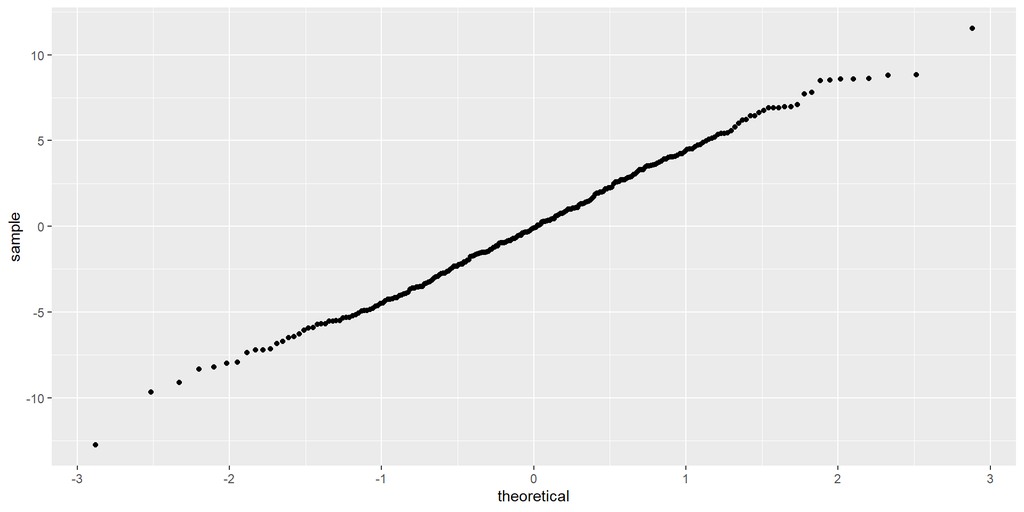

## Scatterplot of residuals and predicted values

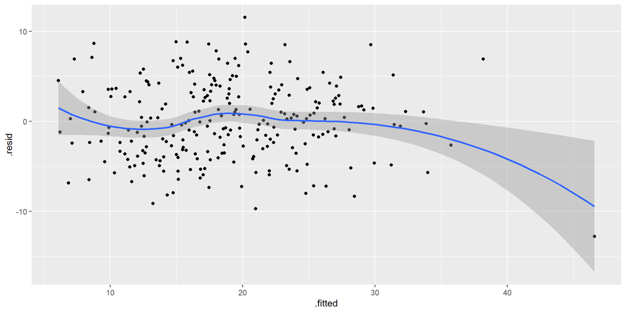

## Measures of influence

- Same as in biostats-1
  - Leverage > 3(p+1)/n
  - Studentized residual > +/-3
  - Cook’s distance > 1

## Live demo, part 3

## Live demo #3, residual plots

## Break #5

- What you have learned
  - Residual analysis
- What’s coming next
  - Collinearity

## What is collinearity?

- Strong interrelationship among the independent variables
  - Also known as
    - multi-collinearity
    - near collinearity
    - ill-conditioning
- Interrelationship could be just two variables
  - Also could be three or more interrelated variables

## Examples of collinearity

- Birthweight and gestational age predicting length of stay
- Size of the home and size of the lot predicting sales price
- Calories from fat, from protein, and from carbohydrates predicting weight gain

## What problems are caused by collinearity?

- Difficulty in variable selection
- Loss of precision
  - wider confidence intervals
- Loss of power
  - Need for larger sample sizes
- Not a violation of assumptions
- Not a problem if you are only interested in prediction

## Fixing collinearity

- Collect more data
- Oversample “rare” corners
- Prune your variables

## Measures of collinearity

- Correlation matrix
- Tolerance
  - $Tol_i=1-R_i^2$
    - $R_i^2$ for predicting $i^{th}$ independent variable from remaining independent variables
- Variance inflation factor
  - $VIF_i=\frac{1}{Tol_i}$
  - Increase in $Var(\hat\beta_i)$ due to collinearity

## Collinearity statistics for the fat dataset

```
   chest  abdomen      hip
6.340574 8.383840 4.332385
```

## What is perfect collinearity?

- Exact relationship among independent variables
- Impossible to estimate regression coefficients
- Examples
  - Measuring temperature in both Fahrenheit and Centigrade
  - Thee percentages adding up to exactly 100%
- Only solution: drop one or more variables

## Live demo, part 4

## Live demo #4, multicollinearity

## Break #6

- What you have learned
  - Collinearity
- What’s coming next
  - Mediation

## What is mediation?

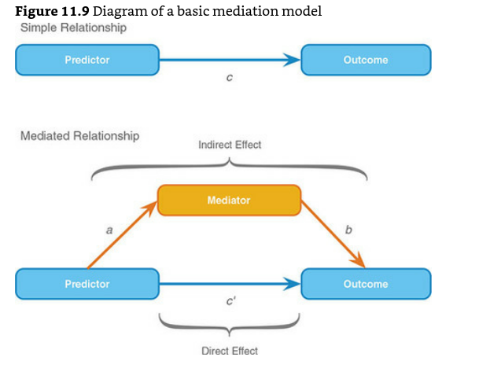

- “A situation when the relationship between a predictor variable and an outcome variable can be explained by their relationship to a third variable (the mediator)”
  - Andy Field, Section 11.4

## Why do you need to understand mediation?

- Mostly irrelevant for prediction
- Very important for understanding mechanisms
  - Is there a direct relationship?

## An informal assessment of mediation

Model without the mediator

```
# A tibble: 2 × 5
  term        estimate std.error statistic       p.value
  <chr>          <dbl>     <dbl>     <dbl>         <dbl>
1 (Intercept)   11.0      1.74        6.31 0.00000000125
2 age            0.178    0.0372      4.78 0.00000304
```

Model with the mediator

```
# A tibble: 3 × 5
  term        estimate std.error statistic  p.value
  <chr>          <dbl>     <dbl>     <dbl>    <dbl>
1 (Intercept) -36.5       2.47      -14.8  6.23e-36
2 age           0.0660    0.0229      2.88 4.27e- 3
3 abdomen       0.567     0.0268     21.2  1.19e-57
```

## Live demo, part 5

## Live demo #5, mediation

## Summary

- What you have learned
  - Three models for predicting a continuous outcome
  - Analysis of variance table
  - Variable selection
  - Stepwise regression
  - Residual analysis
  - Collinearity
  - Mediation